# improveR: Workflows

# 5 makeStepsRelative

`makeStepsRelative` takes all steps constituting a workflow and makes them relative to each other, meaning it adds to each step information on its relation with other steps. For this purpose two new columns are added to the dataframe: `dependenicies` and `usage`.

`dependencies` contains the handle id(s) of one or more steps on which the step in question depends on. Generally, the dependency is due to linkage to files created by the steps featured under `dependencies`. In other words, steps in `dependencies` are `to the left` in the lineage of the respective step; they are ‘upstream’ in the data analysis workflow.

`usage` features those steps which use the output created by the step in question. In other words, these steps are ‘to the right’ in the lineage of the respective step; they are ‘downstream’ in the data analysis workfow.

Steps which are at the end of a workflow (leaves) do not feature usage steps. Root steps do not feature dependencies.

By linking each step’s own handle with the handles of its dependency and usage steps, it becomes possible to represent the complete workflow.

**Make steps relative**

```r
print(identTargetStep)
## [1] "envhost1.hc.scintecodev.internal-5310:ST-62516"

tic()
workflowLineage <- getFullLineage(ident=identTargetStep) %>%
improveR::makeStepsRelative() %>%
improveR::retrieveWorkflow()
tic()

class(workflowLineage)
## [1] "data.frame"
names(workflowLineage)
##  [1] "handle"         "processes"      "treeIdent"      "treeName"       "treePath"       "description"    "entityId"       "remoteFiles"    "workflowHandle" "rationale"      "dependencies"   "usage"
glimpse(workflowLineage)
## Rows: 12
## Columns: 12
## $ handle         <chr> "534e89cb-6b75-432d-9023-bd5ee4963e99", "5961f7df-86c3-4879-8a51-154b929fdf1f", "85260abf-03d1-4bf1-abbb-921373ab84e8", "ef8918b8-5701-4699-b434-d55dcbab0063", "cd15c7ec-0702-4e23-9bed-98f5d9221450", "67f2c05c-17c1-47d6-9c4c-6a71eefa42d0", "f5e649f1-538c-40f0-9a31-a884e89394d1", "d08cdc13-a22a-4aa5-9850-b8e6ea6d9fb1", "8b4ddee2-6922-4c44-a82d-a407e6097a9b", "d644474c-b99b-4863-859d-5e2543e8ac48", "1900a466-bd28-4b1c-a1cc-e787694c5c03", "eb0b2609-0ecf-4d44-a7a7-44a354b7a620"
## $ processes      <list> [<data.frame[1 x 13]>], [<data.frame[1 x 13]>], [<data.frame[1 x 12]>], [<data.frame[1 x 13]>], [<data.frame[1 x 13]>], [<data.frame[1 x 13]>], [<data.frame[1 x 13]>], [<data.frame[1 x 13]>], [<data.frame[1 x 13]>], [<data.frame[1 x 13]>], [<data.frame[1 x 13]>], [<data.frame[1 x 13]>]
## $ treeIdent      <chr> "9978BAEF59D8403C86FEB9E8379DF557", "D0A5C735170C4DE3AE39FF67A7331A7C", "98C32486D1F6462793768B22909ED58E", "A0D580FB7DE64E5690BCEBAEC951141C", "A0D580FB7DE64E5690BCEBAEC951141C", "D0A5C735170C4DE3AE39FF67A7331A7C", "D0A5C735170C4DE3AE39FF67A7331A7C", "A0D580FB7DE64E5690BCEBAEC951141C", "D0A5C735170C4DE3AE39FF67A7331A7C", "A0D580FB7DE64E5690BCEBAEC951141C", "A0D580FB7DE64E5690BCEBAEC951141C", "A0D580FB7DE64E5690BCEBAEC951141C"
## $ treeName       <chr> "Reporting", "EDA", "DataOrder", "Modeling", "Modeling", "EDA", "EDA", "Modeling", "EDA", "Modeling", "Modeling", "Modeling"
## $ treePath       <chr> "/improve-tutorial", "/improve-tutorial", "/improve-tutorial", "/improve-tutorial", "/improve-tutorial", "/improve-tutorial", "/improve-tutorial", "/improve-tutorial", "/improve-tutorial", "/improve-tutorial", "/improve-tutorial", "/improve-tutorial"
## $ description    <chr> "Collect results and create report", "Analyse dynamics of concentration over time", "Checks data set for missing data", "Create combined regression table for Jama", "Model 1: Duration ~ Wt", "Create subject level data. Transforms data set from panel structure to cross-section structure for individual subject data.", "Conduct explenatory data analysis.", "Model: Duration ~ Wt+Age+Sex", "Tables of Step 6 are reproduced using JAMA theme.", "Model 2: Duration ~ Wt + Sex", "Model: Duration ~ Wt + Age", "Compare performances of different model specifications"
## $ entityId       <chr> "ST-62516", "ST-54049", "ST-54627", "ST-59463", "ST-54635", "ST-54047", "ST-57280", "ST-54675", "ST-59046", "ST-54651", "ST-54672", "ST-54678"
## $ remoteFiles    <list> [<tbl_df[23 x 10]>], [<tbl_df[8 x 11]>], [<tbl_df[9 x 9]>], [<tbl_df[11 x 11]>], [<tbl_df[10 x 11]>], [<tbl_df[7 x 11]>], [<tbl_df[16 x 11]>], [<tbl_df[10 x 11]>], [<tbl_df[13 x 11]>], [<tbl_df[10 x 11]>], [<tbl_df[10 x 11]>], [<tbl_df[10 x 11]>]
## $ workflowHandle <chr> "8e8b8e93-386f-4078-971b-38274f22b22b", "8e8b8e93-386f-4078-971b-38274f22b22b", "8e8b8e93-386f-4078-971b-38274f22b22b", "8e8b8e93-386f-4078-971b-38274f22b22b", "8e8b8e93-386f-4078-971b-38274f22b22b", "8e8b8e93-386f-4078-971b-38274f22b22b", "8e8b8e93-386f-4078-971b-38274f22b22b", "8e8b8e93-386f-4078-971b-38274f22b22b", "8e8b8e93-386f-4078-971b-38274f22b22b", "8e8b8e93-386f-4078-971b-38274f22b22b", "8e8b8e93-386f-4078-971b-38274f22b22b", "8e8b8e93-386f-4078-971b-38274f22b22b"
## $ rationale      <chr> NA, "additional EDA", "Ensures missing data are accounted for before proceeding with analysis.", "Model results", "Check linear relationship between duration and weight", "EDA", "Get EDA", "Extend model 1 by including Age and Sex as an additional explanatory variable;\r\nCheck linear relationship between duration and weight as well as age and sex.", "Get EDA", "Extend model 1 by including Sex as an additional explanatory variable;\r\nCheck linear relationship between duration and weight as well as sex.", "Extend model 1 by including Age as an additional explanatory variable;\r\nCheck linear relationship between duration and weight as well as age.", "Model results"
## $ dependencies   <chr> "5961f7df-86c3-4879-8a51-154b929fdf1f,ef8918b8-5701-4699-b434-d55dcbab0063,cd15c7ec-0702-4e23-9bed-98f5d9221450,85260abf-03d1-4bf1-abbb-921373ab84e8,f5e649f1-538c-40f0-9a31-a884e89394d1,d08cdc13-a22a-4aa5-9850-b8e6ea6d9fb1,8b4ddee2-6922-4c44-a82d-a407e6097a9b,d644474c-b99b-4863-859d-5e2543e8ac48,d644474c-b99b-4863-859d-5e2543e8ac48,1900a466-bd28-4b1c-a1cc-e787694c5c03,85260abf-03d1-4bf1-abbb-921373ab84e8,eb0b2609-0ecf-4d44-a7a7-44a354b7a620,d08cdc13-a22a-4aa5-9850-b8e6ea6d9fb1,f5e649f1-538c-40f0-9a31-a884e89394d1,f5e649f1-538c-40f0-9a31-a884e89394d1,cd15c7ec-0702-4e23-9bed-98f5d9221450,5961f7df-86c3-4879-8a51-154b929fdf1f,1900a466-bd28-4b1c-a1cc-e787694c5c03", "85260abf-03d1-4bf1-abbb-921373ab84e8,67f2c05c-17c1-47d6-9c4c-6a71eefa42d0", NA, "1900a466-bd28-4b1c-a1cc-e787694c5c03,d644474c-b99b-4863-859d-5e2543e8ac48,cd15c7ec-0702-4e23-9bed-98f5d9221450,d08cdc13-a22a-4aa5-9850-b8e6ea6d9fb1", "67f2c05c-17c1-47d6-9c4c-6a71eefa42d0", "85260abf-03d1-4bf1-abbb-921373ab84e8", "67f2c05c-17c1-47d6-9c4c-6a71eefa42d0,67f2c05c-17c1-47d6-9c4c-6a71eefa42d0", "67f2c05c-17c1-47d6-9c4c-6a71eefa42d0", "67f2c05c-17c1-47d6-9c4c-6a71eefa42d0,67f2c05c-17c1-47d6-9c4c-6a71eefa42d0", "67f2c05c-17c1-47d6-9c4c-6a71eefa42d0", "67f2c05c-17c1-47d6-9c4c-6a71eefa42d0", "1900a466-bd28-4b1c-a1cc-e787694c5c03,cd15c7ec-0702-4e23-9bed-98f5d9221450,d08cdc13-a22a-4aa5-9850-b8e6ea6d9fb1,d644474c-b99b-4863-859d-5e2543e8ac48"
## $ usage          <chr> NA, "534e89cb-6b75-432d-9023-bd5ee4963e99,534e89cb-6b75-432d-9023-bd5ee4963e99", "534e89cb-6b75-432d-9023-bd5ee4963e99,534e89cb-6b75-432d-9023-bd5ee4963e99,5961f7df-86c3-4879-8a51-154b929fdf1f,67f2c05c-17c1-47d6-9c4c-6a71eefa42d0", "534e89cb-6b75-432d-9023-bd5ee4963e99", "534e89cb-6b75-432d-9023-bd5ee4963e99,534e89cb-6b75-432d-9023-bd5ee4963e99,ef8918b8-5701-4699-b434-d55dcbab0063,eb0b2609-0ecf-4d44-a7a7-44a354b7a620", "5961f7df-86c3-4879-8a51-154b929fdf1f,cd15c7ec-0702-4e23-9bed-98f5d9221450,f5e649f1-538c-40f0-9a31-a884e89394d1,f5e649f1-538c-40f0-9a31-a884e89394d1,d08cdc13-a22a-4aa5-9850-b8e6ea6d9fb1,8b4ddee2-6922-4c44-a82d-a407e6097a9b,8b4ddee2-6922-4c44-a82d-a407e6097a9b,d644474c-b99b-4863-859d-5e2543e8ac48,1900a466-bd28-4b1c-a1cc-e787694c5c03", "534e89cb-6b75-432d-9023-bd5ee4963e99,534e89cb-6b75-432d-9023-bd5ee4963e99,534e89cb-6b75-432d-9023-bd5ee4963e99", "534e89cb-6b75-432d-9023-bd5ee4963e99,534e89cb-6b75-432d-9023-bd5ee4963e99,ef8918b8-5701-4699-b434-d55dcbab0063,eb0b2609-0ecf-4d44-a7a7-44a354b7a620", "534e89cb-6b75-432d-9023-bd5ee4963e99", "534e89cb-6b75-432d-9023-bd5ee4963e99,534e89cb-6b75-432d-9023-bd5ee4963e99,ef8918b8-5701-4699-b434-d55dcbab0063,eb0b2609-0ecf-4d44-a7a7-44a354b7a620", "534e89cb-6b75-432d-9023-bd5ee4963e99,534e89cb-6b75-432d-9023-bd5ee4963e99,ef8918b8-5701-4699-b434-d55dcbab0063,eb0b2609-0ecf-4d44-a7a7-44a354b7a620", "534e89cb-6b75-432d-9023-bd5ee4963e99"
```

**relative relations by dependencies and usage (scroll right to see full table)**

```r
workflowLineage %>%
select(handle, entityId, description, dependencies, usage)
##                                  handle entityId                                                                                                                 description                                                                                                                                                                                                                                                                                                                                                                                                                                                                                                                                                                                                                                                                              dependencies                                                                                                                                                                                                                                                                                                                                        usage
## 1  534e89cb-6b75-432d-9023-bd5ee4963e99 ST-62516                                                                                           Collect results and create report 5961f7df-86c3-4879-8a51-154b929fdf1f,ef8918b8-5701-4699-b434-d55dcbab0063,cd15c7ec-0702-4e23-9bed-98f5d9221450,85260abf-03d1-4bf1-abbb-921373ab84e8,f5e649f1-538c-40f0-9a31-a884e89394d1,d08cdc13-a22a-4aa5-9850-b8e6ea6d9fb1,8b4ddee2-6922-4c44-a82d-a407e6097a9b,d644474c-b99b-4863-859d-5e2543e8ac48,d644474c-b99b-4863-859d-5e2543e8ac48,1900a466-bd28-4b1c-a1cc-e787694c5c03,85260abf-03d1-4bf1-abbb-921373ab84e8,eb0b2609-0ecf-4d44-a7a7-44a354b7a620,d08cdc13-a22a-4aa5-9850-b8e6ea6d9fb1,f5e649f1-538c-40f0-9a31-a884e89394d1,f5e649f1-538c-40f0-9a31-a884e89394d1,cd15c7ec-0702-4e23-9bed-98f5d9221450,5961f7df-86c3-4879-8a51-154b929fdf1f,1900a466-bd28-4b1c-a1cc-e787694c5c03                                                                                                                                                                                                                                                                                                                                         <NA>
## 2  5961f7df-86c3-4879-8a51-154b929fdf1f ST-54049                                                                                 Analyse dynamics of concentration over time                                                                                                                                                                                                                                                                                                                                                                                                                                                                                                                                                                                                                 85260abf-03d1-4bf1-abbb-921373ab84e8,67f2c05c-17c1-47d6-9c4c-6a71eefa42d0                                                                                                                                                                                                                                                                    534e89cb-6b75-432d-9023-bd5ee4963e99,534e89cb-6b75-432d-9023-bd5ee4963e99
## 3  85260abf-03d1-4bf1-abbb-921373ab84e8 ST-54627                                                                                            Checks data set for missing data                                                                                                                                                                                                                                                                                                                                                                                                                                                                                                                                                                                                                                                                                      <NA>                                                                                                                                                                                          534e89cb-6b75-432d-9023-bd5ee4963e99,534e89cb-6b75-432d-9023-bd5ee4963e99,5961f7df-86c3-4879-8a51-154b929fdf1f,67f2c05c-17c1-47d6-9c4c-6a71eefa42d0
## 4  ef8918b8-5701-4699-b434-d55dcbab0063 ST-59463                                                                                   Create combined regression table for Jama                                                                                                                                                                                                                                                                                                                                                                                                                                                                                                                                       1900a466-bd28-4b1c-a1cc-e787694c5c03,d644474c-b99b-4863-859d-5e2543e8ac48,cd15c7ec-0702-4e23-9bed-98f5d9221450,d08cdc13-a22a-4aa5-9850-b8e6ea6d9fb1                                                                                                                                                                                                                                                                                                         534e89cb-6b75-432d-9023-bd5ee4963e99
## 5  cd15c7ec-0702-4e23-9bed-98f5d9221450 ST-54635                                                                                                      Model 1: Duration ~ Wt                                                                                                                                                                                                                                                                                                                                                                                                                                                                                                                                                                                                                                                      67f2c05c-17c1-47d6-9c4c-6a71eefa42d0                                                                                                                                                                                          534e89cb-6b75-432d-9023-bd5ee4963e99,534e89cb-6b75-432d-9023-bd5ee4963e99,ef8918b8-5701-4699-b434-d55dcbab0063,eb0b2609-0ecf-4d44-a7a7-44a354b7a620
## 6  67f2c05c-17c1-47d6-9c4c-6a71eefa42d0 ST-54047 Create subject level data. Transforms data set from panel structure to cross-section structure for individual subject data.                                                                                                                                                                                                                                                                                                                                                                                                                                                                                                                                                                                                                                                      85260abf-03d1-4bf1-abbb-921373ab84e8 5961f7df-86c3-4879-8a51-154b929fdf1f,cd15c7ec-0702-4e23-9bed-98f5d9221450,f5e649f1-538c-40f0-9a31-a884e89394d1,f5e649f1-538c-40f0-9a31-a884e89394d1,d08cdc13-a22a-4aa5-9850-b8e6ea6d9fb1,8b4ddee2-6922-4c44-a82d-a407e6097a9b,8b4ddee2-6922-4c44-a82d-a407e6097a9b,d644474c-b99b-4863-859d-5e2543e8ac48,1900a466-bd28-4b1c-a1cc-e787694c5c03
## 7  f5e649f1-538c-40f0-9a31-a884e89394d1 ST-57280                                                                                          Conduct explenatory data analysis.                                                                                                                                                                                                                                                                                                                                                                                                                                                                                                                                                                                                                 67f2c05c-17c1-47d6-9c4c-6a71eefa42d0,67f2c05c-17c1-47d6-9c4c-6a71eefa42d0                                                                                                                                                                                                                               534e89cb-6b75-432d-9023-bd5ee4963e99,534e89cb-6b75-432d-9023-bd5ee4963e99,534e89cb-6b75-432d-9023-bd5ee4963e99
## 8  d08cdc13-a22a-4aa5-9850-b8e6ea6d9fb1 ST-54675                                                                                                Model: Duration ~ Wt+Age+Sex                                                                                                                                                                                                                                                                                                                                                                                                                                                                                                                                                                                                                                                      67f2c05c-17c1-47d6-9c4c-6a71eefa42d0                                                                                                                                                                                          534e89cb-6b75-432d-9023-bd5ee4963e99,534e89cb-6b75-432d-9023-bd5ee4963e99,ef8918b8-5701-4699-b434-d55dcbab0063,eb0b2609-0ecf-4d44-a7a7-44a354b7a620
## 9  8b4ddee2-6922-4c44-a82d-a407e6097a9b ST-59046                                                                           Tables of Step 6 are reproduced using JAMA theme.                                                                                                                                                                                                                                                                                                                                                                                                                                                                                                                                                                                                                 67f2c05c-17c1-47d6-9c4c-6a71eefa42d0,67f2c05c-17c1-47d6-9c4c-6a71eefa42d0                                                                                                                                                                                                                                                                                                         534e89cb-6b75-432d-9023-bd5ee4963e99
## 10 d644474c-b99b-4863-859d-5e2543e8ac48 ST-54651                                                                                                Model 2: Duration ~ Wt + Sex                                                                                                                                                                                                                                                                                                                                                                                                                                                                                                                                                                                                                                                      67f2c05c-17c1-47d6-9c4c-6a71eefa42d0                                                                                                                                                                                          534e89cb-6b75-432d-9023-bd5ee4963e99,534e89cb-6b75-432d-9023-bd5ee4963e99,ef8918b8-5701-4699-b434-d55dcbab0063,eb0b2609-0ecf-4d44-a7a7-44a354b7a620
```

```r
## 11 1900a466-bd28-4b1c-a1cc-e787694c5c03 ST-54672                                                                                                  Model: Duration ~ Wt + Age                                                                                                                                                                                                                                                                                                                                                                                                                                                                                                                                                                                                                                                      67f2c05c-17c1-47d6-9c4c-6a71eefa42d0                                                                                                                                                                                          534e89cb-6b75-432d-9023-bd5ee4963e99,534e89cb-6b75-432d-9023-bd5ee4963e99,ef8918b8-5701-4699-b434-d55dcbab0063,eb0b2609-0ecf-4d44-a7a7-44a354b7a620
## 12 eb0b2609-0ecf-4d44-a7a7-44a354b7a620 ST-54678                                                                      Compare performances of different model specifications                                                                                                                                                                                                                                                                                                                                                                                                                                                                                                                                       1900a466-bd28-4b1c-a1cc-e787694c5c03,cd15c7ec-0702-4e23-9bed-98f5d9221450,d08cdc13-a22a-4aa5-9850-b8e6ea6d9fb1,d644474c-b99b-4863-859d-5e2543e8ac48                                                                                                                                                                                                                                                                                                         534e89cb-6b75-432d-9023-bd5ee4963e99
```

# 6 ‘detach’ functions

When working with workflows it can be helpful to detach a workflow from its resources or trees. This facilitates the workflow’s portability which is needed when it comes e.g. to execute the workflow with a different source data set or modify its desired eventual outcome report.

In this context, there are three functions which come into play: `detachStep()`, `detachWorkflowFromResources()`, and`detachWorkflowFromTrees()`.

## 6.1 detachStep()

`detachStep` removes a step from its parent step. A child step becomes a rootstep. The step remains located in the its analysis tree.

*Note*: The column `parentId` in the step data frame contains the resource id of the Analysis Tree in which the step is located. *`parentId` does not refer to the parent step of the step in question*.

To demonstrate the function’s use, let’s detach Step 6 in analysis tree ‘Modeling’.

```r
identStep6 <- "envhost1.hc.scintecodev.internal-5310:ST-54651"

step6ATModeling_beforeDetach <- loadResource(ident = identStep6) #load step 6 of AT Modeling

step6ATModeling_detached <- improveR::detachStep(ident = identStep6)
```

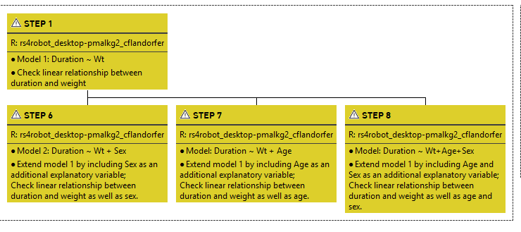

Analysis Tree structure before detaching step

After applying `detachStep`, the step - previously a child step - becomes a root step in its analysis tree.

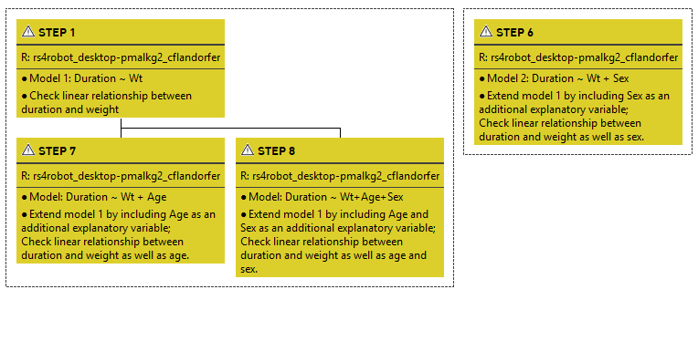

Analysis Tree structure after detaching step

Note that there is no information in the data frame pertaining to Step 6 which would indicate that the step is no longer an ‘attached’ child step but has become a root step. The step’s `parentId` is still the resource id of the analysis tree in which the step is located. However, a) checking for a parent step via `loadParentStep()` returns NULL, and b) checking the children of the parent step Step 1 reveals that Step 6 is no longer appearing among the child steps.

**Check (previous) parent step after detachStep**

```r
# Step 6 no longer features a parent step anymore
loadParentStep(ident = identStep6)
## NULL

# Step 1 (the former parent step) no longer features
# Step 6 as a child (only other children)
identStep1 <- "envhost1.hc.scintecodev.internal-5310:ST-54635"
step1AT <- loadResource(ident = identStep1)$parentId
step1ChildSteps <- loadChildSteps(ident = identStep1)

step1ChildSteps$data %>%
    list_rbind() %>%
    filter(parentId == step1AT) %>% # check only steps within the same AT
    select(entityId, name, description) # Step 1 no longer features Step 6 among its child steps
##   entityId   name                  description
## 1 ST-54672 Step 7   Model: Duration ~ Wt + Age
## 2 ST-54675 Step 8 Model: Duration ~ Wt+Age+Sex
```

### 6.1.1 attachStep()

The conceptual coutnerpart of `detachStep` is `attachStep()` which adds a step to a parent step.

**attachStep**

```r
#Step 1 of AT Modeling
identParentStep1 <- "envhost1.hc.scintecodev.internal-5310:ST-54635"

step6ATModeling_afterAtach <- attachStep(
    ident = identStep6,
    parent = identParentStep1
)
step6ATModeling_afterAtach
##                         resourceId                  description                                                                                                                                       rationale                resourceVersionId nodeType   name                         parentId deleted entityId entityVersionId                       revisionId lastModifiedOn                 lastModifiedById fileSize hasChildren hasChildrenIncludingFiles                              path outdatedLink toolCategory                           toolId runStatus keyStep baseModel fullModel finalModel referenceModel                        ownedById processType processName                                               runserverUrl runserverLocal runserverReproducible                                                  runserver  lastModifiedOnDate isVersion
## 1 9C3323B91A244AAABABFEDE65287891E Model 2: Duration ~ Wt + Sex Extend model 1 by including Sex as an additional explanatory variable;\r\nCheck linear relationship between duration and weight as well as sex. 1F693270057948EF9AFCF581646518B0     Step Step 6 A0D580FB7DE64E5690BCEBAEC951141C   FALSE ST-54651      ST-54651-1 44CAFAE699BB434F95A2134FA069B9D7   1.745398e+12 98E5D50FCFE64B6B8128C35ADA89BA4D        0       FALSE                     FALSE /improve-tutorial/Modeling/Step 6        FALSE        rlang 2252CD501F67456987429F101831FCF1  FINISHED   FALSE     FALSE     FALSE      FALSE          FALSE 1594E8ED57E6C30BE063030011ACA58C        main        Main http://envhost1.hc.scintecodev.internal:5330/runserver/run          FALSE                 FALSE http://envhost1.hc.scintecodev.internal:5330/runserver/run 2025-04-23 10:39:25     FALSE
```

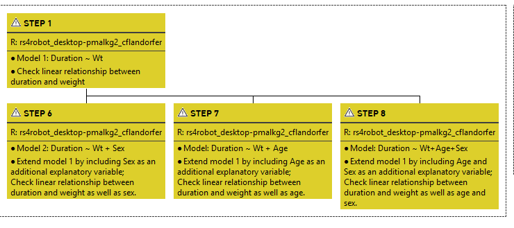

Analysis Tree structure after (re-)attaching step

**Check step after attachStep**

```r
loadParentStep(ident = identStep6) # returns parent step, i.e. Step 1 of AT Modeling
##                         resourceId            description                                             rationale                resourceVersionId nodeType   name                         parentId deleted entityId entityVersionId                       revisionId lastModifiedOn                 lastModifiedById fileSize hasChildren hasChildrenIncludingFiles                              path outdatedLink toolCategory                           toolId runStatus keyStep baseModel fullModel finalModel referenceModel                        ownedById processType processName                                               runserverUrl runserverLocal runserverReproducible                                                  runserver  lastModifiedOnDate isVersion
## 1 70BF16ADD9484B7EA0A933B72544C2A3 Model 1: Duration ~ Wt Check linear relationship between duration and weight 2D539FBA2314464F8E79E3A8BCC76D06     Step Step 1 A0D580FB7DE64E5690BCEBAEC951141C   FALSE ST-54635      ST-54635-1 F33610474FF54B07970CABD4B3987F7D   1.745397e+12 98E5D50FCFE64B6B8128C35ADA89BA4D        0       FALSE                     FALSE /improve-tutorial/Modeling/Step 1        FALSE        rlang 2252CD501F67456987429F101831FCF1  FINISHED   FALSE     FALSE     FALSE      FALSE          FALSE 1594E8ED57E6C30BE063030011ACA58C        main        Main http://envhost1.hc.scintecodev.internal:5330/runserver/run          FALSE                 FALSE http://envhost1.hc.scintecodev.internal:5330/runserver/run 2025-04-23 10:25:08     FALSE

identStep1 <- "envhost1.hc.scintecodev.internal-5310:ST-54635"
step1AT <- loadResource(ident = identStep1)$parentId #get resourceId of Analysis Tree
step1ChildSteps <- loadChildSteps(ident = identStep1)

step1ChildSteps$data %>%
    list_rbind() %>%
    filter(parentId == step1AT) %>% # check only steps within the same AT
    select(entityId, name, description) # Step 6 is features as a child step of Step 1
##   entityId   name                  description
## 1 ST-54672 Step 7   Model: Duration ~ Wt + Age
## 2 ST-54651 Step 6 Model 2: Duration ~ Wt + Sex
## 3 ST-54675 Step 8 Model: Duration ~ Wt+Age+Sex
```

## 6.2 detachWorkflowFromResources()

`detachWorkflowFromResources` deletes all entity ids from a workflow data dataframe. After applying `detachWorflowFromResources` the dataframe no longer contains a column with the name `entityId`.

In the context of this function ‘resources’ refers to the steps, including their related files, constitutiong the workflow. After applying the function the ‘substance’ of the steps and their related files are still part of the workflow, but they are now detached from the steps’ idents. #IMPROVEMENT #CHECK

Note that the function only returns the workflowHandle as an output to the console. The changes made to the dataframe are not visibly returned.

**detachWorkflowFromResources: Apply function**

```r
#Get names of workflow dataframe to demonstrate function's consequence
identTargetStep <- "envhost1.hc.scintecodev.internal-5310:ST-62516" #Step 1 of AT Reporting
#get workflow elements; df has entityId column
workflowHandle_demoDetach <- improveR::getFullLineage(identTargetStep)
## 2025-06-25 10:00:00.862742 INFO::refreshing token

workflowResourceAttached <- workflowHandle_demoDetach %>%
improveR::retrieveWorkflow()

names(workflowResourceAttached)
##  [1] "handle"         "processes"      "treeIdent"      "treeName"       "treePath"       "description"    "entityId"       "remoteFiles"    "workflowHandle" "rationale"
"entityId" %in% names(workflowResourceAttached)
## [1] TRUE

#Detach workflow from resources
#Note that the function prints the workflowHandleTargetStep as output.
workflowHandle_demoDetach %>%
    detachWorkflowFromResources()
## [1] "731840b7-acb1-464e-bcac-9e5dedee57e7"

workflowResourcesDetached <- workflowHandle_demoDetach %>%
improveR::retrieveWorkflow()

#entityId column is no longer present
"entityId" %in% names(workflowResourcesDetached)
## [1] FALSE
```